# Socioeconomic Factors on Individuals

Donna Te, Jiajia Lin, Steven He

11/14/2022

### Summary

```
## $covid_num_observations
## [1] 3710
##
## $covid_max_death_ratio_by_race
## [1] "Non-Hispanic American Indian or Alaska Native"
##
## $covid_max_death_by_race
## [1] "Non-Hispanic White"
##
## $ari_max_LIN_state
## [1] "New York"
##
## $ari_max_HIW_state
## [1] "New York"
```

In total, there were `3710` rows of covid observations. Of these observations, it was found that the greatest number of deaths when observed by race were `non-hispanic white` individuals. This was an interesting finding, but could be impacted by numerous factors such as oppression. Oftentimes, people of color may not seek medical attention due to legal or financial reasons, and omissions of these minorities may go unrecorded. We also looked at the race that has the maximum deaths ratio. The result was `non-hispanic American Indian or Alaska Native`, who are minorities. Because they are minorities, there are many injustices that result in this outcome such as environmental, healthcare, rights, and much more.

As for the second dataset, the state that has the greatest number of low income non-white population weighted concreation was `New York`, and this was the same for the high income white population. From these results, we believe that `New York` was the outcome for both findings due to the fact that `New York` consumes more fossil fuels in its buildings than any other states in the country. To explain the outcome between the two opposite demographics, it may be reliant on the fact that `New York` is the fifth-most diverse state but also has one of the greatest income gaps. For these reasons, the combination of diversity in race and income results in `New York`.

### Table

```r
covid_by_race
```

```
##                                                     race population_2020
## 1                                               Hispanic        61312879
## 2                                     Non-Hispanic White       196773390
## 3                                     Non-Hispanic Black        41427341
## 4                                     Non-Hispanic Asian        19367197
## 5 Non-Hispanic Native Hawaiian or Other Pacific Islander          613507
## 6          Non-Hispanic American Indian or Alaska Native         2432338
## 7                                                  Other         7557471
##   total_deaths proportion_of_covid_death
## 1       688440               0.011228310
## 2      2846786               0.014467332
## 3       618389               0.014927074
## 4       136057               0.007025126
## 5         8714               0.014203587
## 6        47434               0.019501402
## 7        28315               0.003746624
```

From this aggregated table, we were able to see that Non-Hispanic White individuals had the greatest number of deaths. Although at first glance it was surprising, when observing the proportion of covid deaths, it revealed a significant finding. Because the number of non-white hispanic individuals who were recorded in data was so large, there was also a large number of deaths. Upon looking at the proportions, Non-Hispanic American Indian or Alaska Native and Non-Hispanic Black individuals had the highest proportion of deaths due to covid.

### Chart 1

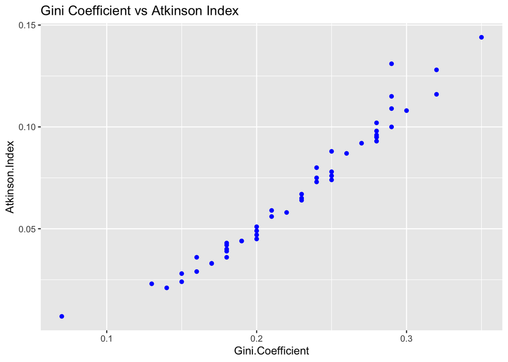

### Chart 2

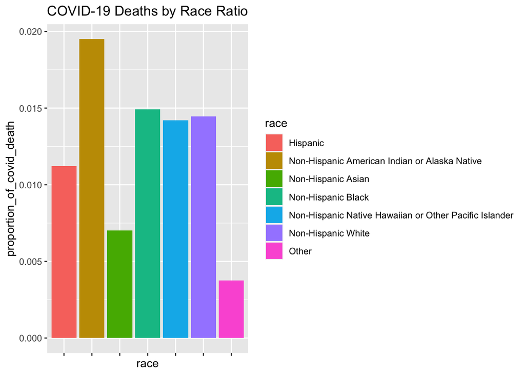